# Exercises lecture 3 – data wrangling

Paolo Crosetto

9/11/2019

# `filter()` & `select()`

## Exercice 1

> sauvegardez dans un nouvel objet tous les vols partis entre midi et deux heures, en gardant juste l’info sur l’aéroport de départ et d’arrivée

```r
df <- flights

temp <- filter(df, dep_time>1200 & dep_time <1400)
ex1 <- select(temp, origin, dest)
ex1
```

```
## # A tibble: 32,558 x 2
##    origin dest
##    <chr>  <chr>
##  1 EWR    BTV
##  2 EWR    SJU
##  3 EWR    ATL
##  4 JFK    SFO
##  5 EWR    MCO
##  6 EWR    IAH
##  7 EWR    BUF
##  8 JFK    HOU
##  9 EWR    CLT
## 10 EWR    ORD
## # … with 32,548 more rows
```

```r
df %>%
  filter(dep_time>1200 & dep_time <1400) %>%
  select(origin, dest)
```

```
## # A tibble: 32,558 x 2
##    origin dest
##    <chr>  <chr>
##  1 EWR    BTV
##  2 EWR    SJU
##  3 EWR    ATL
##  4 JFK    SFO
##  5 EWR    MCO
##  6 EWR    IAH
##  7 EWR    BUF
##  8 JFK    HOU
##  9 EWR    CLT
## 10 EWR    ORD
## # … with 32,548 more rows
```

## Exercice 2

> isolez dans un nouvel objet tous les vols partis entre minuit et une heure du matin de JFK et de LGA. Quelle est, pour chacun de deux aéroport, la destionation la plus fréquente?

```r
df %>%
  filter(dep_time >= 0 & dep_time <= 100) %>%
  filter(origin %in% c("JFK", "LGA")) -> ex2
table(ex2$origin, ex2$dest)
```

```
##
##       ATL AUS BGR BHM BNA BOS BQN BTV BUF CAK CLE CLT CMH CVG DCA DEN DFW
##   JFK   1   5   0   0   0  29  90  23  36   0   1   1   1   1   3   6   0
##   LGA  11   0   1   1   5   3   0   2   0   8   0   3   0   0   4   1   1
##
##       DSM DTW FLL IAD IAH JAX LAS LAX MCO MDW MHT MIA MKE MSN MSP MSY ORD
##   JFK   0   0  14   3   0   6   8  24  15   0   0   0   0   0   0   5   1
##   LGA   1   4  23   1   2   0   0   0  11  15   5   2   2   1   1   0   6
##
##       PBI PDX PHL PHX PIT PSE PWM RDU RIC ROC SAN SAT SEA SFO SJU SLC SYR
##   JFK   4   3   1   1   0 118  18   6   1  26   1   1   1   4 112   1  25
##   LGA   0   0   0   0   2   0   1   3   2   0   0   0   0   0   0   0   5
##
##       TPA
##   JFK  10
##   LGA   2
```

## Exercice 3

> y a-t-il une rélation entre heure de départ et retard au départ? répondez avec un plot (geom_point + geom_smooth)

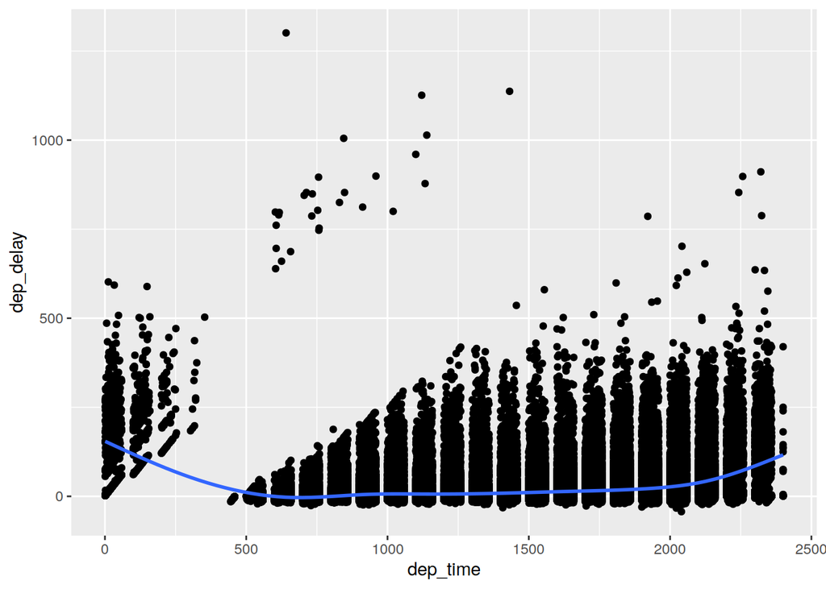

```r
df %>%
  ggplot(aes(dep_time, dep_delay)) +
  geom_point()+
  geom_smooth()
```

# `mutate()`

## Exercice 4

> créez une variable qui montre la vitesse de chaque avion

```r
df %>%
  mutate(vitesse = distance / air_time,
         kmh = vitesse*60*1.60934) %>%
  select(kmh, vitesse, distance, air_time, everything())
```

```
## # A tibble: 336,776 x 21
##      kmh vitesse distance air_time  year month   day dep_time
##    <dbl>   <dbl>    <dbl>    <dbl> <int> <int> <int>    <int>
##  1  596.    6.17     1400      227  2013     1     1      517
##  2  602.    6.24     1416      227  2013     1     1      533
##  3  657.    6.81     1089      160  2013     1     1      542
##  4  832.    8.61     1576      183  2013     1     1      544
##  5  634.    6.57      762      116  2013     1     1      554
##  6  463.    4.79      719      150  2013     1     1      554
##  7  651.    6.74     1065      158  2013     1     1      555
##  8  417.    4.32      229       53  2013     1     1      557
##  9  651.    6.74      944      140  2013     1     1      557
## 10  513.    5.31      733      138  2013     1     1      558
## # … with 336,766 more rows, and 13 more variables: sched_dep_time <int>,
## #   dep_delay <dbl>, arr_time <int>, sched_arr_time <int>,
## #   arr_delay <dbl>, carrier <chr>, flight <int>, tailnum <chr>,
## #   origin <chr>, dest <chr>, hour <dbl>, minute <dbl>, time_hour <dttm>
```

## Exercice 5

> créez une variable qui calcule l’impact (en %) du retard à l’arrivée sur le temps de vol

```r
df %>%
  mutate(impact_retard_pct = (100*arr_delay)/air_time) %>%
  select(impact_retard_pct, arr_delay, air_time, everything())
```

```
## # A tibble: 336,776 x 20
##    impact_retard_p… arr_delay air_time  year month   day dep_time
##               <dbl>     <dbl>    <dbl> <int> <int> <int>    <int>
##  1             4.85        11      227  2013     1     1      517
##  2             8.81        20      227  2013     1     1      533
##  3            20.6         33      160  2013     1     1      542
##  4            -9.84       -18      183  2013     1     1      544
##  5           -21.6        -25      116  2013     1     1      554
##  6             8           12      150  2013     1     1      554
##  7            12.0         19      158  2013     1     1      555
##  8           -26.4        -14       53  2013     1     1      557
##  9            -5.71        -8      140  2013     1     1      557
## 10             5.80         8      138  2013     1     1      558
## # … with 336,766 more rows, and 13 more variables: sched_dep_time <int>,
## #   dep_delay <dbl>, arr_time <int>, sched_arr_time <int>, carrier <chr>,
## #   flight <int>, tailnum <chr>, origin <chr>, dest <chr>, distance <dbl>,
## #   hour <dbl>, minute <dbl>, time_hour <dttm>
```

# `summarise()` and `group_by()`

## Exercice 6

> calculez la moyenne, l’écart type, le min et le max du rétard à l’arrivée

```r
df %>%
  summarise(moyenne = mean(arr_delay, na.rm = T),
            ecart_type = sd(arr_delay, na.rm = T),
            min = min(arr_delay, na.rm = T),
            max = max(arr_delay, na.rm = T))
```

```
## # A tibble: 1 x 4
##   moyenne ecart_type   min   max
##     <dbl>      <dbl> <dbl> <dbl>
## 1    6.90       44.6   -86  1272
```

## Exercice 7

```r
df %>%
  filter(carrier == "AA") %>%
  group_by(origin) %>%
  summarise(moyenne = mean(arr_delay, na.rm = T),
            ecart_type = sd(arr_delay, na.rm = T),
            min = min(arr_delay, na.rm = T),
            max = max(arr_delay, na.rm = T))
```

```
## # A tibble: 3 x 5
##   origin moyenne ecart_type   min   max
##   <chr>    <dbl>      <dbl> <dbl> <dbl>
## 1 EWR      0.978       48.3   -67   878
## 2 JFK      2.08        43.9   -75  1007
## 3 LGA     -1.33        39.7   -68   802
```

## Exercice 8

> plottez la moyenne du retard par compagnie aérienne

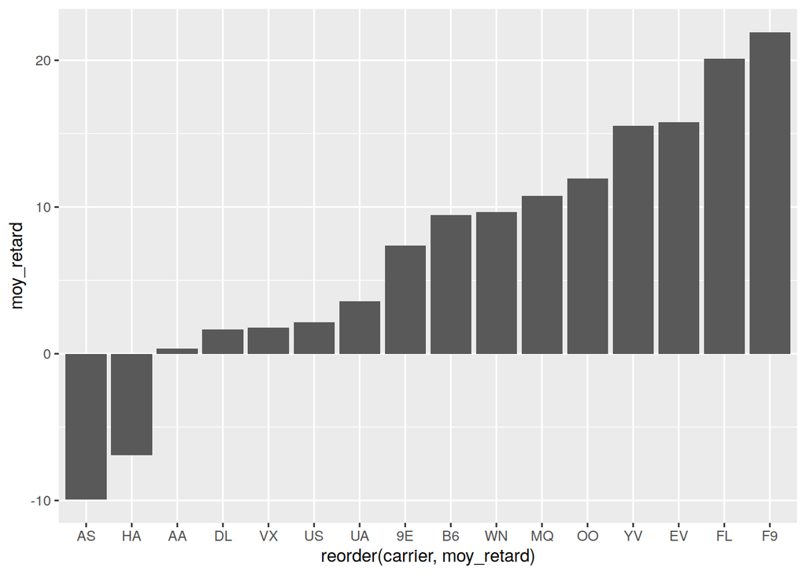

```r
df %>%
  group_by(carrier) %>%
  summarise(moy_retard = mean(arr_delay, na.rm = T)) %>%
  ggplot(aes(x = reorder(carrier, moy_retard), y = moy_retard)) +
  geom_col()
```

## Exercice 9 – filter + select + mutate + summarise + group_by

> quelle est la vitesse moyenne des vols qui partent entre 11h et 13h, par mois?

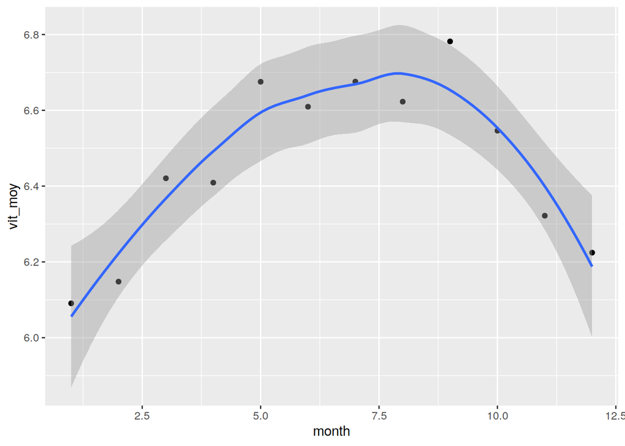

```r
df %>%
  filter(dep_time > 1100 & dep_time < 1300) %>%
  mutate(vitesse = distance / air_time) %>%
  group_by(month) %>%
  summarise(vit_moy = mean(vitesse, na.rm = T)) %>%
  ggplot(aes(x = month, y = vit_moy))+
   geom_point()+geom_smooth()
```

# meet the pipe: `%>%`

## meta-exercice 1

> **re-faites** *tous* les exercices ci-dessus en utilisant l’opérateur ‘et après’ / pipe `%>%`

## Exercice 10

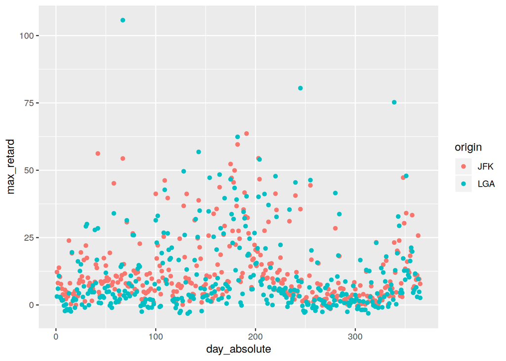

```r
df %>%
  filter(origin %in% c("JFK", "LGA")) %>%
  group_by(origin, month, day) %>%
  summarise(max_retard = mean(dep_delay, na.rm = T)) %>%
  mutate(day_year = paste(day, month, sep='.')) %>%
  group_by(origin) %>%
  mutate(day_absolute = row_number()) %>%
  ggplot(aes(x = day_absolute, y = max_retard, color = origin)) +
  geom_point()
```

## Exercice 11

> de quel aéroport partent les vols à plus longue distance?

# `join_...()` family of functions

> first run thi setup R code chunk. It will load in your workspace 3 data frames:
- **airports**: avec données sur les aéroports américains
- **flights**: qu’on connait déjà
- **planes**: avec les données pour chaque avion

```r
planes <- planes
flights <- flights
airports <- airports
```

## Exercice 12

> est-ce que les routes plus longues sont desservies apr les avions les plus modernes?

*notes*: utilisez `left_join()` et mergez les dataframes `flights` et `planes`

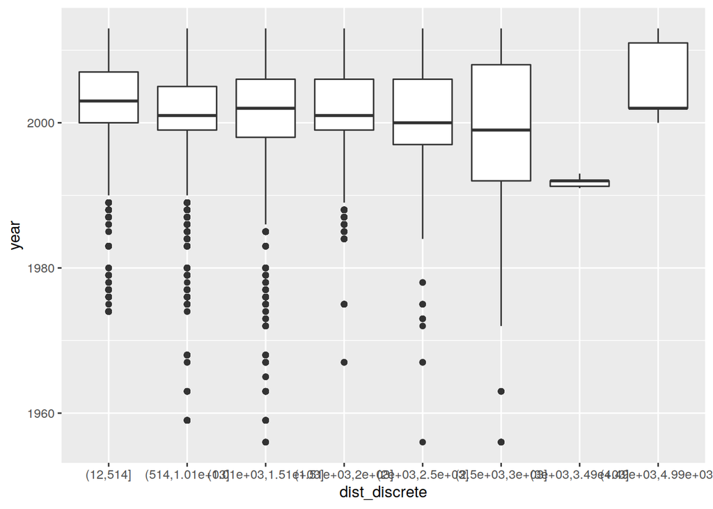

```r
df %>%
  select(tailnum, distance) %>%
  left_join(planes, by = "tailnum") %>%
  mutate(dist_discrete = cut(distance, breaks = 10)) %>%
  ggplot(aes(x = dist_discrete, y = year))+
  geom_boxplot()
```

## Exercice 13

> combien de vols qui partent des trois aéroport de NY atterrissent dans des destinations au dessus de 1000m s.n.m.?

```r
flights %>%
  select(origin, dest) %>%
  left_join(airports, by = c("dest" = "faa")) %>%
  mutate(altitude_m = alt/3.28) %>%
  filter(altitude_m > 1000) %>%
  group_by(origin) %>%
  summarise(nombre_des_vols = n())
```

```
## # A tibble: 3 x 2
##   origin nombre_des_vols
##   <chr>            <int>
## 1 EWR               3412
## 2 JFK               3175
## 3 LGA               3704
```

# creating tidy data: reshape with `gather()` and `spread()`

## Exercice 14

> tidy world_bank_pop dataset so that ‘year’ is a variable and for each country and each year you have urban population and urban population growh only. Plot as a geom_line the total population for each country over the years.